# Classification on Cheese dataset: Hierarchical Agglomerative Clustering (HAC) and K-means

13 octobre, 2020

**Tags:** #Exercice #Clustering #HAC #Kmeans

### Introduction

*Fromage* dataset is a dataset containing 29 fromages and their nutritional information. The goal of this exercice is to determine groups of homogenous cheeses based on the nutritional information.

I’m using Hierarchical Agglomerative Clustering (HAC) and K-means algorithms on this dataset.

*This exercice is taken from the [teaching page of Marie Chavent](http://www.math.u-bordeaux.fr/~mchave100p/teaching/) (University of Bordeaux).*

### Importing dataset. Descriptive Statistics

```r
dta <- read.table("DATA/fromage.txt", header=TRUE, row.names=1)
```

```r
head(dta) %>%
  kbl(caption = "Extract of Cheese dataset") %>%
  kable_minimal(font_size = 12, bootstrap_options=c("stripped", "hover"), full_width=F, position="left")
```

Extract of Cheese dataset

|  | calories | sodium | calcium | lipides | retinol | folates | proteines | cholesterol | magnesium |
| --- | --- | --- | --- | --- | --- | --- | --- | --- | --- |
| CarredelEst | 314 | 353.5 | 72.6 | 26.3 | 51.6 | 30.3 | 21.0 | 70 | 20 |
| Babybel | 314 | 238.0 | 209.8 | 25.1 | 63.7 | 6.4 | 22.6 | 70 | 27 |
| Beaufort | 401 | 112.0 | 259.4 | 33.3 | 54.9 | 1.2 | 26.6 | 120 | 41 |
| Bleu | 342 | 336.0 | 211.1 | 28.9 | 37.1 | 27.5 | 20.2 | 90 | 27 |
| Camembert | 264 | 314.0 | 215.9 | 19.5 | 103.0 | 36.4 | 23.4 | 60 | 20 |
| Cantal | 367 | 256.0 | 264.0 | 28.8 | 48.8 | 5.7 | 23.0 | 90 | 30 |

Basic statistics

|  | calories | sodium | calcium | lipides | retinol | folates | proteines | cholesterol | magnesium |
| --- | --- | --- | --- | --- | --- | --- | --- | --- | --- |
|  | Min. : 70 | Min. : 22.0 | Min. : 72.6 | Min. : 3.40 | Min. : 37.10 | Min. : 1.20 | Min. : 4.10 | Min. : 10.00 | Min. :10.00 |
|  | 1st Qu.:292 | 1st Qu.:140.0 | 1st Qu.:132.9 | 1st Qu.:23.40 | 1st Qu.: 51.60 | 1st Qu.: 4.90 | 1st Qu.:17.80 | 1st Qu.: 70.00 | 1st Qu.:20.00 |
|  | Median :321 | Median :223.0 | Median :202.3 | Median :26.30 | Median : 62.30 | Median : 6.40 | Median :21.00 | Median : 80.00 | Median :26.00 |
|  | Mean :300 | Mean :210.1 | Mean :185.7 | Mean :24.16 | Mean : 67.56 | Mean :13.01 | Mean :20.17 | Mean : 74.59 | Mean :26.97 |
|  | 3rd Qu.:355 | 3rd Qu.:276.0 | 3rd Qu.:220.5 | 3rd Qu.:29.10 | 3rd Qu.: 76.40 | 3rd Qu.:21.10 | 3rd Qu.:23.40 | 3rd Qu.: 90.00 | 3rd Qu.:30.00 |
|  | Max. :406 | Max. :432.0 | Max. :334.6 | Max. :33.30 | Max. :150.50 | Max. :36.40 | Max. :35.70 | Max. :120.00 | Max. :51.00 |

Quick glance at standard deviation for each variable

|  | Standard deviation |
| --- | --- |
| proteines | 6.96 |
| lipides | 8.13 |
| magnesium | 11.32 |
| folates | 11.72 |
| retinol | 24.16 |
| cholesterol | 28.25 |
| calcium | 72.53 |
| calories | 91.91 |
| sodium | 108.68 |

- Range of values values differ strongly between variables
- Standard deviation ranges from approximatively 7 to 108 units
- No missing values for any of the variables

Given the variations of the variables standardization is necessary.

#### Correlations

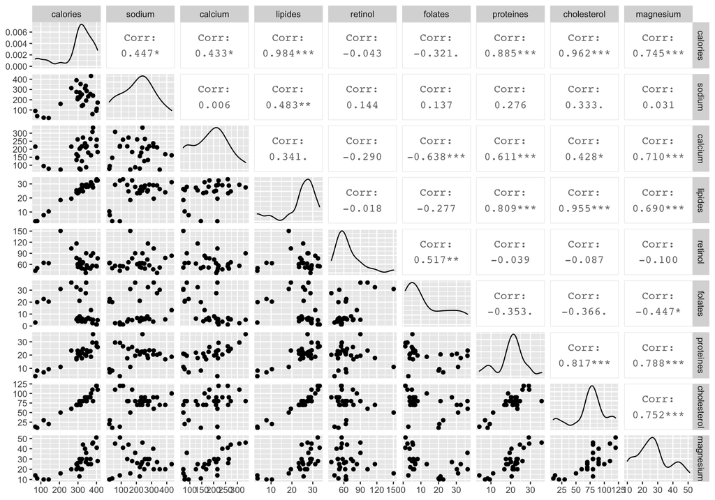

```r
ggpairs(dta)
```

There seems to be strong links between some variables. For example we have a strong positive correlation between *calories* and *lipides*, or *lipides* and *cholesterol*, or a negative correlation between *calcium* and *folates*.

#### Data standardization

```r
n <- nrow(dta)
dta_standard <- as.data.frame(scale(dta, center=TRUE,scale=TRUE)*sqrt(n/(n-1)))

round(dta_standard[1:4,1:4], 2) %>%
  kbl(caption = "Quick glance at standardized data", align="l") %>%
  kable_minimal(font_size = 12, bootstrap_options=c("stripped", "hover"), full_width=F, position="left")
```

Quick glance at standardized data

|  | calories | sodium | calcium | lipides |
| --- | --- | --- | --- | --- |
| CarredelEst | 0.15 | 1.34 | -1.59 | 0.27 |
| Babybel | 0.15 | 0.26 | 0.34 | 0.12 |
| Beaufort | 1.12 | -0.92 | 1.03 | 1.14 |
| Bleu | 0.46 | 1.18 | 0.36 | 0.59 |

```r
summary(dta_standard) %>%
  kbl(caption = "Basic statistics on standardized data", align="l") %>%
  kable_minimal(font_size = 12, bootstrap_options=c("stripped", "hover"), full_width=F, position="left")
```

Basic statistics on standardized data

|  | calories | sodium | calcium | lipides | retinol | folates | proteines | cholesterol | magnesium |
| --- | --- | --- | --- | --- | --- | --- | --- | --- | --- |
|  | Min. :-2.54700 | Min. :-1.7613 | Min. :-1.5875 | Min. :-2.59865 | Min. :-1.2830 | Min. :-1.0253 | Min. :-2.3497 | Min. :-2.3271 | Min. :-1.52547 |
|  | 1st Qu.:-0.08896 | 1st Qu.:-0.6563 | 1st Qu.:-0.7414 | 1st Qu.:-0.09497 | 1st Qu.:-0.6723 | 1st Qu.:-0.7041 | 1st Qu.:-0.3464 | 1st Qu.:-0.1652 | 1st Qu.:-0.62631 |
|  | Median : 0.23214 | Median : 0.1209 | Median : 0.2324 | Median : 0.26807 | Median :-0.2216 | Median :-0.5738 | Median : 0.1215 | Median : 0.1951 | Median :-0.08682 |
|  | Mean : 0.00000 | Mean : 0.0000 | Mean : 0.0000 | Mean : 0.00000 | Mean : 0.0000 | Mean : 0.0000 | Mean : 0.0000 | Mean : 0.0000 | Mean : 0.00000 |
|  | 3rd Qu.: 0.60859 | 3rd Qu.: 0.6172 | 3rd Qu.: 0.4878 | 3rd Qu.: 0.61858 | 3rd Qu.: 0.3722 | 3rd Qu.: 0.7023 | 3rd Qu.: 0.4725 | 3rd Qu.: 0.5554 | 3rd Qu.: 0.27285 |
|  | Max. : 1.17328 | Max. : 2.0781 | Max. : 2.0888 | Max. : 1.14435 | Max. : 3.4932 | Max. : 2.0305 | Max. : 2.2710 | Max. : 1.6363 | Max. : 2.16108 |

### Hierarchical Agglomerative Clustering (HAC) using Ward algorithm

```r
# calculating euclidean distance
d <- dist(dta_standard) # calculating the distance

# HAC
tree <- hclust(d^2/(2*n), method="ward.D")
```

#### Choosing number of classes

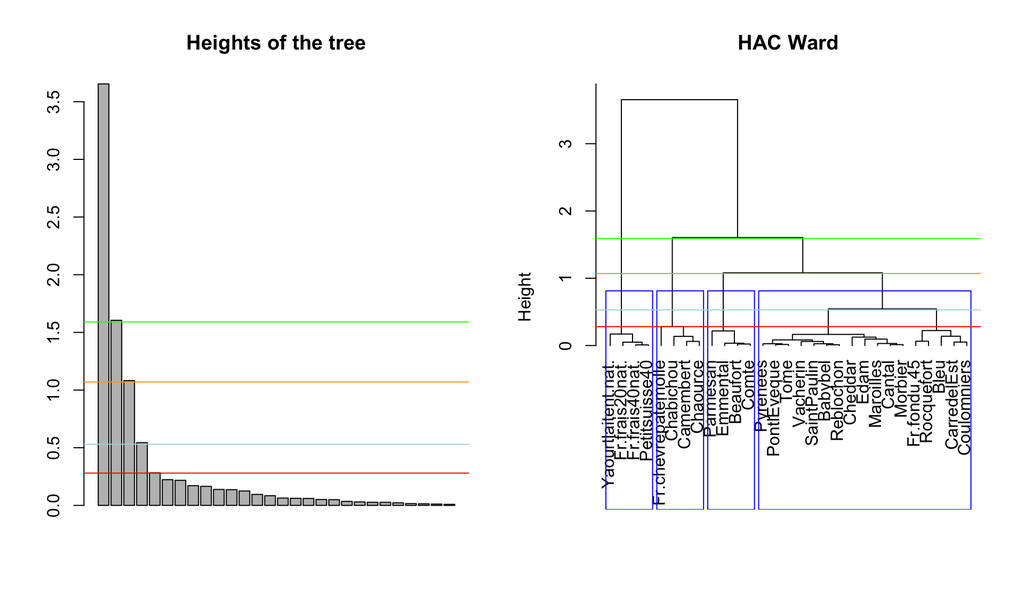

```r
par(mfrow=c(1,2))
barplot(sort(tree$height, decreasing = TRUE), main="Heights of the tree")
abline(h=0.28, col="red")
abline(h=0.53, col="lightblue")
abline(h=1.07, col="orange")
abline(h=1.59, col="green")

plot(tree, hang=-1, main="HAC Ward", sub="", xlab="")
rect.hclust(tree, k=4, border="blue")
abline(h=0.28, col="red")
abline(h=0.53, col="lightblue")
abline(h=1.07, col="orange")
abline(h=1.59, col="green")
```

Judgind by the heights of the tree branches (barplot), last important loss of information happens between 3 and 4 classes, so 4 is retained.

#### Assigning cheeses to respective classes based on the HAC tree

A new variable *hac* is created to store cheeses and assignes classes. Then the classes and the original dataset (dta) are merged in *hac* object.

```r
K <- 4 # number of classes
hac <- cutree(tree,k=K)

hac <- as.data.frame(as.factor(hac))
hac <- cbind(hac, dta)
colnames(hac)[1] <- c("cluster_HAC")
```

### Clustering with K-means

I’m using the results of HAC to define the initial number of clusters. K-means is initialized with 4 classes.

```r
km <- kmeans(dta, centers=4) # k-means with 4
```

The classes and the original dataset (*dta*) are merged in *k.means* object.

```r
k.means <- as.data.frame(as.factor(km$cluster), row.names = FALSE) # to get the results of clustering
k.means <- cbind(k.means, dta)
colnames(k.means)[1] <- c("cluster_KM")
```

This classification explains 73.13% of total inertia, which is slightly lower than HAC, but remains a good representation.

### Quick comparaison of HAC and K-means clustering

```r
# Data preparation
temp <- cutree(tree, 4)
dta_clustering <- cbind(as.factor(temp), as.factor(km$cluster), dta)
colnames(dta_clustering)[1:2] <- c("cluster_HAC", "cluster_KM")

hac.table <- table(dta_clustering$cluster_KM, dnn="cluster")
km.table <- table(dta_clustering$cluster_HAC, dnn="cluster")
```

```r
kbl(list(hac.table, km.table), caption = "HAC vs. K-means classification results", align="l") %>%
  kable_minimal(font_size = 12, bootstrap_options=c("stripped", "hover"), full_width=F, position="left")
```

| cluster | Freq |
| --- | --- |
| 1 | 5 |
| 2 | 8 |
| 3 | 6 |
| 4 | 10 |

| cluster | Freq |
| --- | --- |
| 1 | 17 |
| 2 | 4 |
| 3 | 4 |
| 4 | 4 |

```r
table(dta_clustering$cluster_HAC,dta_clustering$cluster_KM)
```

```
##
##     1 2 3 4
##   1 0 6 3 8
##   2 0 0 3 1
##   3 1 2 0 1
##   4 4 0 0 0
```

Let’s look at the details now: which cheeses are in which cluster.

```r
sapply(unique(dta_clustering$cluster_HAC), function(g) rownames(dta_clustering)[dta_clustering$cluster_HAC==g]) %>%
  kbl(caption = "Clustering results - HAC algorithm", align="l") %>%
  kable_minimal(font_size = 12, bootstrap_options=c("stripped", "hover"), full_width=F, position="left")
```

Clustering results - HAC algorithm

| x |
| --- |
| CarredelEst |
| Babybel |
| Bleu |
| Cantal |
| Cheddar |
| Coulomniers |
| Edam |
| Fr.fondu.45 |
| Maroilles |
| Morbier |
| PontlEveque |
| Pyrenees |
| Reblochon |
| Rocquefort |
| SaintPaulin |
| Tome |
| Vacherin |

| x |
| --- |
| Beaufort |
| Comte |
| Emmental |
| Parmesan |

| x |
| --- |
| Camembert |
| Chabichou |
| Chaource |
| Fr.chevrepatemolle |

| x |
| --- |
| Fr.frais20nat. |
| Fr.frais40nat. |
| Petitsuisse40 |
| Yaourtlaitent.nat. |

```r
sapply(unique(dta_clustering$cluster_KM), function(g) rownames(dta_clustering)[dta_clustering$cluster_KM==g]) %>%
  kbl(caption = "Clustering results - K-means algorithm", align="l") %>%
  kable_minimal(font_size = 12, bootstrap_options=c("stripped", "hover"), full_width=F, position="left")
```

Clustering results - K-means algorithm

| x |
| --- |
| CarredelEst |
| Chabichou |
| Chaource |
| Coulomniers |
| Fr.fondu.45 |
| PontlEveque |
| Rocquefort |
| Tome |

| x |
| --- |
| Babybel |
| Bleu |
| Camembert |
| Cantal |
| Maroilles |
| Morbier |
| Parmesan |
| Pyrenees |
| Reblochon |
| SaintPaulin |

| x |
| --- |
| Beaufort |
| Cheddar |
| Comte |
| Edam |
| Emmental |
| Vacherin |

| x |
| --- |
| Fr.chevrepatemolle |
| Fr.frais20nat. |
| Fr.frais40nat. |
| Petitsuisse40 |
| Yaourtlaitent.nat. |